November 2026

Sociologist · Bamberg, Germany

# Florian Schulz

Sociologist and empirical researcher, interested in families, life courses, time use and inequality.

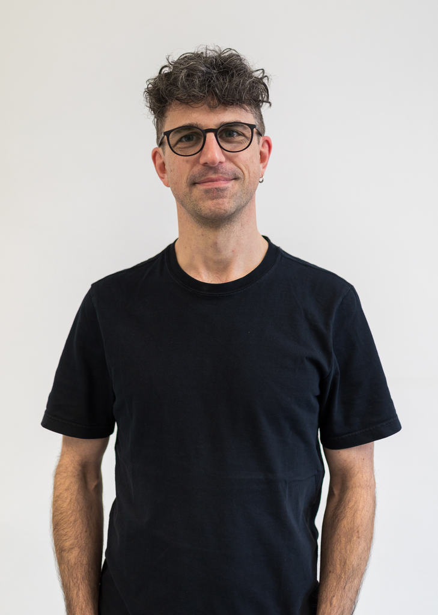

**Interests**

Families Life courses Time use Inequality

**Position**

Senior Researcher, [State Institute for Family Research (ifb)](https://ifb.bayern.de/)

**Teaching**

Private Lecturer for Sociology, [University of Bamberg](https://www.uni-bamberg.de/), [Institute for Sociology](https://www.uni-bamberg.de/soziologie/)

**Service**

Editor and Managing Director, [Journal of Family Research](https://ubp.uni-bamberg.de/jfr/index.php/jfr)

[ORCID](https://orcid.org/0000-0002-3865-6668) [Web of Science](https://www.webofscience.com/wos/author/record/850082) [Google Scholar](https://scholar.google.de/citations?user=MWCt6hQAAAAJ&hl)

Email [Bluesky](https://bsky.app/profile/flociologist.bsky.social) [OSF](https://osf.io/ju4hp/) [GitHub](https://github.com/flociologist) [ifb profile](https://www.ifb.bayern.de/ueber/mitarbeiterinnen/schulz.php)

## Data & visualizations

- 2026 [How many hours per week do the mother and father work when the youngest child is … years old?](https://doi.org/10.17605/osf.io/wux29) OSF
- 2026 [Selected attitudes towards the division of labor in heterosexual couples in Germany, 2023](https://doi.org/10.17605/osf.io/edpgf) OSF
- 2025 [Update of the analysis in “Trends in children’s gendered housework performance”](https://doi.org/10.17605/osf.io/ghz6y) OSF

## Recent preprints

- 2026 [Convergence and continuity of time use for housework and childcare in German couples, 1991-2022](https://doi.org/10.31235/osf.io/t68dy_v3) SocArXiv
- 2026 [From leaving home to parenthood: Sibling bonds through household and family formation](https://doi.org/10.31235/osf.io/d3j8x_v1) SocArXiv
- 2026 [Time spent alone or together, household type, and feeling lonely: Descriptive evidence from Germany](https://doi.org/10.31235/osf.io/49yru_v2) SocArXiv

## Recent publications

- 2025 [A research note on the cohabitation gradient in parents’ childcare time in Germany](https://osf.io/ubcep) Journal of Time Use Research open access
- 2025 [Young adults’ gendered trajectories of routine housework time when leaving home](https://doi.org/10.1111/jomf.13053) Journal of Marriage and Family open access
- 2024 [Couples’ money arrangements in Germany: Visualizing cohort, age group, and partnership type variations](https://doi.org/10.1177/23780231241301458) Socius open access

## Once upon a time

- 2021 [Mothers’, fathers’ and siblings’ housework time within family households](https://doi.org/10.1111/jomf.12762) Journal of Marriage and Family open access
- 2018 [Gender convergence in housework time: A life course and cohort perspective](https://doi.org/10.15195/v5.a13) Sociological Science open access
- 2012 [What determines change in the division of housework over the course of marriage?](https://doi.org/10.1177/0268580911423056) International Sociology

Updated November 2026